# Recalling Words

## Background

Many teachers and other educators are interested in understanding how to best deliver new content to students. In general, they have two choices of how to do this.

1. The Meshed Approach
   - Deliver new content while simultaneously reviewing previously understood content.
2. The Before Approach
   - Deliver new content after fully reviewing previously understood content.

A study was performed to determine whether the *Meshed* or *Before* approaches to delivering content had any positive benefits on memory recall.

### Show the Experiment Details

Individuals were seated at a computer and shown a list of words. Words appeared on the screen one at a time, for two seconds each, until all words had been shown (40 total). After all words were shown, they were required to perform a few two-digit mathematical additions (like 15 + 25) for 15 seconds to avoid immediate memory recall of the words. They were then asked to write down as many of the 40 words as they could remember. They were given a maximum of 5.3 minutes to recall words.

The process of showing words and recalling words was repeated four times with the same list of words each time (four chances to get it right). The presentation of the first trial was the same for all treatment conditions. However, trials 2, 3, and 4 were slightly different for each treatment condition.

The `SFR` group (the control group) stands for Standard Free Recall. In all four trials the same list of 40 words was presented, in a random order each time.

The `Before` group also used the same 40 words during each trial. However, any words that were correctly recalled in a previous trial were presented first, or *before* the words that were not recalled in the last trial. After all the correct words were presented in random order, the non-recalled words were presented in a random order.

The `Meshed` group also used the same 40 words during each trial. However, words that were correctly recalled in a previous trial were alternated with a missed word during the next presentation order.

The data records the number of correctly recalled words (out of the 40 possible) from the fourth trial. Results were obtained for 30 students, 10 in each of the three treatment groups: `SFR`, `Before`, and `Meshed`.

### Show the Data

The results from the study can be found in the `Friendly` data set in R after loading `library(car)`.

Click the “Code” button to see the data.

```r
datatable(Friendly, options=list(lengthMenu = c(3,10,30)))
```

|  | condition | correct |
| --- | --- | --- |
| 1 | SFR | 39 |
| 2 | SFR | 25 |
| 3 | SFR | 37 |
| 4 | SFR | 25 |
| 5 | SFR | 29 |
| 6 | SFR | 39 |
| 7 | SFR | 21 |
| 8 | SFR | 39 |
| 9 | SFR | 24 |
| 10 | SFR | 25 |

[output cut: 20 more lines]

## Analysis

### Introduction

Understanding how information is best retained is a major topic in psychology and education. This study compares two ways of reviewing and introducing new content to see which method helps people remember better. The two methods tested were the Meshed and Before approaches. We wanted to know: does one of these methods actually help students remember more?

To answer this question, we first used a Welch Two Sample t-test, which compares the means (averages) of two groups. The hypotheses were:

### Hypotheses

**Hypotheses for the t test**

$$H_0: \mu_\text{meshed} = \mu_\text{before}$$

$$H_a: \mu_\text{meshed} \neq \mu_\text{before}$$

Here, the null hypothesis (H0) says there’s no difference in average recall scores between the two methods. The alternative hypothesis (Ha) says there is a difference. We used a significance level of $\alpha = 0.05$ for this test.

Because the t-test assumes the data follows a normal distribution, we also used a Wilcoxon rank-sum test (also called the Mann-Whitney U test) to compare the medians instead of the means. This test doesn’t assume normality. The hypotheses for this test were:

**Hypotheses for the Wilcoxon Test**

$$H_0: \text{difference in medians} = 0$$

$$H_a: \text{difference in medians} \neq 0$$
We used the same significance level of $\alpha = 0.05$ for the Wilcoxon test.

### Graphical and Numerical Summaries

We narrowed the dataset to include only the Before and Meshed groups. Then we examined the descriptive statistics.

```r
Friendly <- Friendly %>%
  filter(condition %in% c("Before", "Meshed")) %>%
  droplevels()
```

```r
# Independent Samples t-Test Numerical Summary
pander(favstats(correct~condition, data=Friendly))
```

| condition | min | Q1 | median | Q3 | max | mean | sd | n | missing |
| --- | --- | --- | --- | --- | --- | --- | --- | --- | --- |
| Before | 24 | 37.25 | 39 | 39.75 | 40 | 36.6 | 5.337 | 10 | 0 |
| Meshed | 30 | 36 | 36.5 | 38.75 | 40 | 36.6 | 3.026 | 10 | 0 |

At a first glance, it looks like there is no difference in the two methods’ means. Both of them have 36.6 mean.

We also created a boxplot to visualize the distribution of scores.

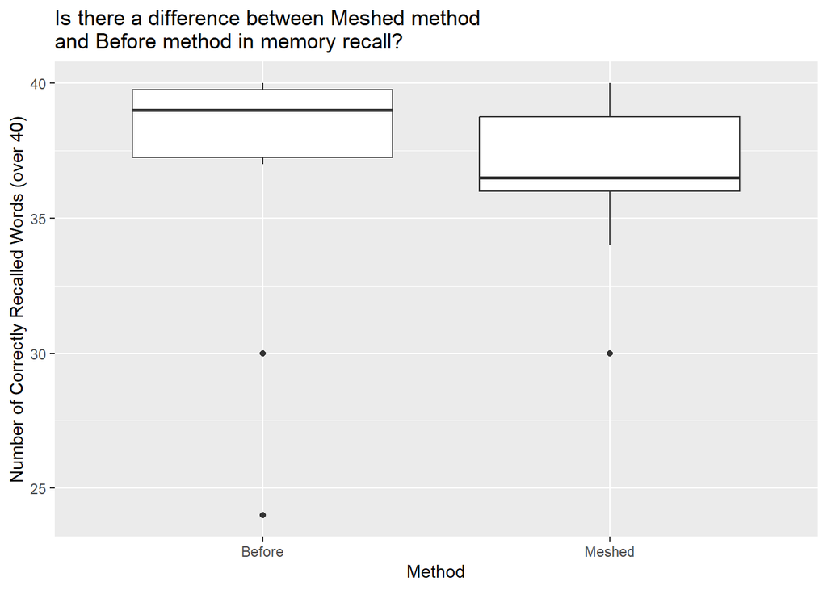

```r
# Independent Samples t-Test Graphic
ggplot(data=Friendly, aes(y=correct, x=condition)) +
  geom_boxplot() +
  labs(title="Is there a difference between Meshed method
and Before method in memory recall?",
      x = "Method",
      y = "Number of Correctly Recalled Words (over 40)")
```

To see if there really is no difference, let’s conduct a two-tailed independent t-Test.

### t-Test

```r
statresult <- t.test(correct~condition, data=Friendly, mu=0, alternative="two.sided", conf.level=0.95)

pander(statresult)
```

Welch Two Sample t-test: `correct` by `condition` (continued below)

| Test statistic | df | P value | Alternative hypothesis |
| --- | --- | --- | --- |
| 0 | 14.24 | 1 | two.sided |

| mean in group Before | mean in group Meshed |
| --- | --- |
| 36.6 | 36.6 |

The Welch Two Sample t-test gave us:

- Test statistic: 0
- Degrees of freedom: 14.24
- p-value: 1

Since the p-value is much higher than our alpha level of 0.05, we fail to reject the null hypothesis. This means we have no reason to believe that the average recall is different between the two methods. Both groups had the exact same mean score of 36.6, so the t-test result makes sense.

But wait, let’s back up of a second here to make sure that doing a t-Test is appropriate for this analysis. To do that, let’s take a look at the distribution of the data.

### Checking Requirements (qqPlot)

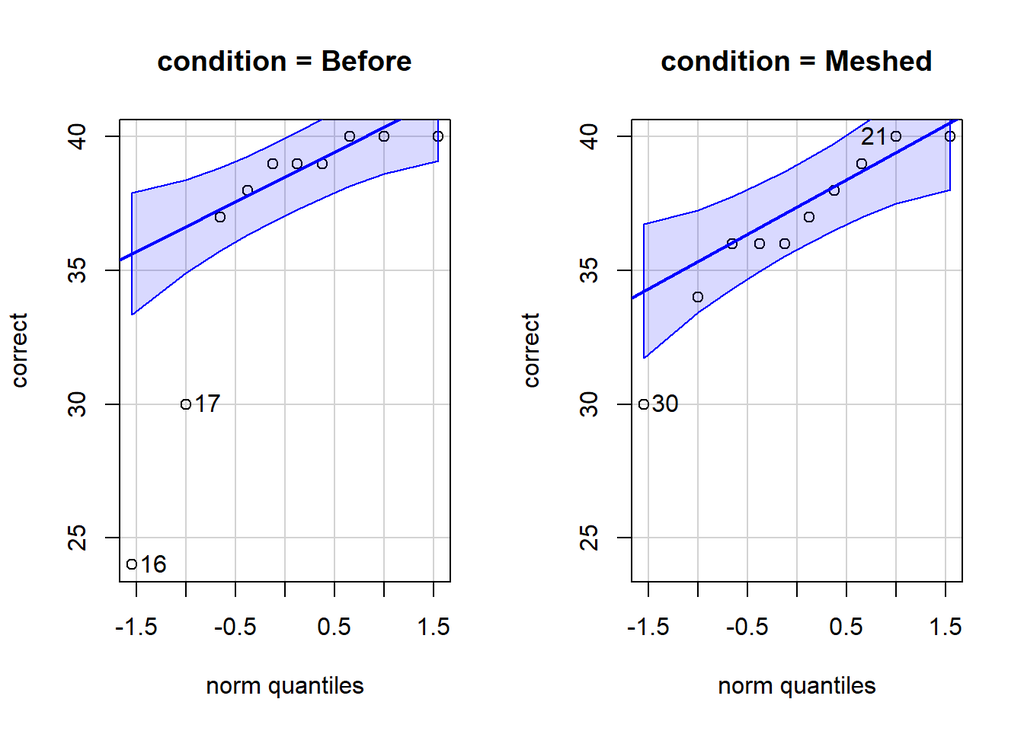

```r
qqPlot(correct~condition, data=Friendly)
```

We used a QQ plot to check if the data followed a normal distribution. Some points did not follow the expected pattern, so the normality assumption may not hold. Because of this, we also ran a non-parametric test.

**Wilcoxon Test**

```r
# Wilcoxon rank-sum test (Mann-Whitney U test)
wilcox_test <- wilcox.test(correct ~ condition, data = Friendly, exact = FALSE)

pander(wilcox_test)
```

| Test statistic | P value | Alternative hypothesis |
| --- | --- | --- |
| 62 | 0.378 | two.sided |

- p-value: 0.378

Since this p-value is also higher than 0.05, we again fail to reject the null hypothesis. There’s no strong evidence of a difference in medians between the two groups.

### Conclusions and Interpretations

Both the t-test and Wilcoxon test showed that there is no statistically significant difference between the Meshed and Before methods in terms of word recall. The t-test produced a p-value of 1, and the Wilcoxon test produced a p-value of 0.378. Both of these are greater than our significance level of 0.05, which means we do not have enough evidence to say one method is better than the other.

This suggests that other factors—like a person’s learning style or how complex the material is—might matter more than the review method. Future studies could explore these factors to find more personalized learning strategies.